# Weight Lifting Exercise

21 November, 2014

Weight Lifting Exercises Dataset

Read more: http://groupware.les.inf.puc-rio.br/har#ixzz3JcqItTYv

# Summary

In this work we’ve applied a three steps process, buidling a classifier with 96.3% accuracy ( 95% CI : (0.957, 0.968) ).  
1. Removing variables with very small amount of information (over 90% is empty) and splitting to training (75%) and testing (25%) sets.  
2. Applying PCA and selecting the first 10 PCA vectors, that account for more than 90% of the variation.  
3. Training a Random Forest model and testing the performance on the test set.

As an additional step, we’ve applied the predictive model on the 20 samples used for submission.

## Data Preperation

```r
train.raw <- read.table("data/pml-training.csv",sep=",",header=TRUE,colClasses=c("character","character","numeric","numeric","Date","character",rep("character",154)))
submission.raw <- read.table("data/pml-testing.csv",sep=",",header=TRUE)
nTrainNA <- apply( train.raw,2,function(x) sum(is.na(x) | x == "" ) )
almostEmptyColumns <- names(which(nTrainNA > 15000))
# after removing the almost-empty columns and the first 6 columns, left with 54 columns (X, timestamp etc), including the "classe" (y)
train.clean.factor <- train.raw[,!( names(train.raw) %in% almostEmptyColumns ) ][,-c(1:6)]
train.clean <- data.frame( data.matrix(train.clean.factor[,-54]), train.clean.factor[,54])
names(train.clean)[54] <- "class"
# remove from the submission the same columns as the one removed from the training, including the last column which is problem_id
submission.factor <- submission.raw[,!( names(submission.raw) %in% almostEmptyColumns ) ][,-c(1:6)][,-54]
submission <- data.frame( data.matrix( submission.factor ) )
```

## Split to Training and Testing sets

```r
inTrain <- createDataPartition(y=train.clean$class,p=0.75,list=FALSE)
training <- train.clean[inTrain,]
testing <- train.clean[-inTrain,]
```

## Apply PCA for Dimensionsality Reduction

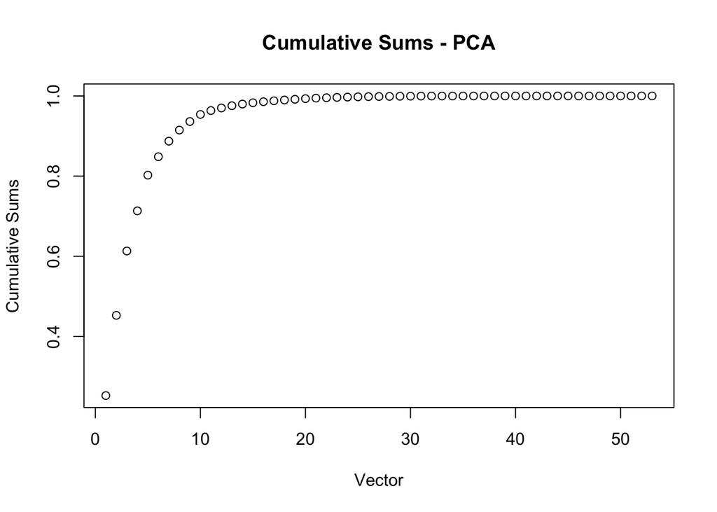

```r
prComp <- prcomp(training[,-54])
plot( cumsum(prComp$sdev^2/sum(prComp$sdev^2)), main = "Cumulative Sums - PCA",xlab="Vector", ylab="Cumulative Sums" )
```

From the plot it’s clear that 10 PCA vectors will cover more tha 90% of the deviation.

## Apply the PCA (top 10 vectors) on the training set

```r
preProc <- preProcess( training[,-54], method="pca", pcaComp = 10)
trainingPC <- predict(preProc,training[,-54])
trainingPCy <- data.frame(trainingPC, training$class)
names(trainingPCy)[11] <- "class"
```

## Train the Random Forest model

```r
modelFitTree <- train(class ~ ., method = "rf", data=trainingPCy)
```

## Apply the model on the testing set

```r
testPC <- predict(preProc,testing[,-54])
predictions <- predict(modelFitTree, testPC)
confusionMatrix(predictions,testing$class)
```

```
## Confusion Matrix and Statistics
##
##           Reference
## Prediction    A    B    C    D    E
##          A 1373   28   13    5    1
##          B    8  896    9    9    3
##          C    9   17  817   31   12
##          D    2    3   11  757    7
##          E    3    5    5    2  878
##
## Overall Statistics
##
##                Accuracy : 0.963
##                  95% CI : (0.957, 0.968)
##     No Information Rate : 0.284
##     P-Value [Acc > NIR] : < 2e-16
##
##                   Kappa : 0.953
##  Mcnemar's Test P-Value : 0.000112
##
## Statistics by Class:
##
##                      Class: A Class: B Class: C Class: D Class: E
## Sensitivity             0.984    0.944    0.956    0.942    0.974
## Specificity             0.987    0.993    0.983    0.994    0.996
## Pos Pred Value          0.967    0.969    0.922    0.971    0.983
## Neg Pred Value          0.994    0.987    0.991    0.989    0.994
## Prevalence              0.284    0.194    0.174    0.164    0.184
## Detection Rate          0.280    0.183    0.167    0.154    0.179
## Detection Prevalence    0.290    0.189    0.181    0.159    0.182
## Balanced Accuracy       0.985    0.968    0.969    0.968    0.985
```

The classifier is fairly accurate, with overallaccuracy of 96.3% and with 95% CI : (0.957, 0.968)

In random forests, there is no need for cross-validation or a separate test set to get an unbiased estimate of the test set error. It is estimated internally, during the run.

For more information, please refer to https://www.stat.berkeley.edu/~breiman/RandomForests/cc_home.htm

## Finally, apply the predictive model on the 20 samples used for submission.

```r
submissionPC <- predict(preProc,submission)
answers <- predict(modelFitTree,submissionPC)
pml_write_files = function(x){
    n = length(x)
    for(i in 1:n){
        filename = paste0("problem_id_",i,".txt")
        write.table(x[i],file=filename,quote=FALSE,row.names=FALSE,col.names=FALSE)
    }
}
pml_write_files(answers)
```